# Projet Analyse de données sur séries globales

Global Impact of the 1980’s regim shift

Abel Zeghidour, Amine Sekourane & Jijun Tang

09 Janvier 2021

# 1 Introduction

## 1.1 Présentation de la problématique

Le jeu de données SERIES GLOBALS a été créé à partir des statistiques disponibles sur le site Global Historical Climatology Network. [L’article](https://onlinelibrary.wiley.com/doi/epdf/10.1111/gcb.13106) traite le phénomène de Regime Shifts et exactement le shift de 1980. Les changements de régime sont des changements importants, brusques et persistants dans la structure et la fonction des écosystèmes, du climat, des systèmes financiers ou d’autres systèmes complexes. Plusieurs faits sont à l’origine de ce changement. L’équipe de chercheurs qui mènent cette recherche font partie d’un grand projet.

Ce dernier vise à réaliser des simulations climatiques de façons coordonnées entre les différents groupes de recherche, permettant une meilleure estimation et compréhension des différences entre les modèles climatiques. Il permet, en outre, d’estimer l’incertitude dû à l’imperfection des modèles dans l’estimation du changement climatique.

Leur rôle est indépendant de l’intervention de l’homme dans le changement globale mais se base plutôt sur l’hypothèse que ce phénomène est une conséquence indirect de l’éruption du Volcan EL Chichon au Mexique. L’éruption de ce dernier est à la cause d’une cascade de changements environnementaux brusques.

## 1.3 variables explicatives

Nous disposons de 18 variables explicatives toutes quantitatives:

- L’indice NAO (hPa) (moyenne hivernale)
- nombre de jours de neige en Suisse (moyenne hivernale)
- Étendu de la couverture en Mer Baltique (10e3 km²)
- Volume de glace de mer en Arctique Septembre (10e3 km^3)
- floraison des cerisiers a Kyoto (jours par ans)
- Arrivée des Hirondelle en Grande Bretagne (jours par ans)
- Débite de la rivière Daugava en Hiver (m^3/s)
- Biomasse phytoplanctonique en Mer du Nord (estimation visuel de la chlorophyllienne)
- Température Océan Arctique ( les température sont toutes en C°)
- Température Pacifique Nord
- Température Océan Atlantique Nord
- Température Europe
- Température Asie
- Température Océan Atlantique Sud
- Anomalies des températures terrestres Globale
- Anomalies des températures Océan Globale

## 1.4 Objectif de l’étude

- déterminer des propriétés spécifiques de nos variables (distribution , relation avec d’autres variables)
- mettre en évidence les tendances potentielles que peuvent suivre ces variables
- création d’un modèle de régression linéaire et multiple

## 1.5 Présentation statistique de notre jeu de donnée

```
##      Annee      indice_NAO_DJFM   Nombre_de_jours_de_neige_en_Suisse_DJFM
##  Min.   :1950   Min.   :-4.8900   Min.   : 2.00
##  1st Qu.:1964   1st Qu.:-1.3300   1st Qu.:12.00
##  Median :1978   Median : 0.2700   Median :19.50
##  Mean   :1978   Mean   : 0.1971   Mean   :23.25
##  3rd Qu.:1991   3rd Qu.: 1.5400   3rd Qu.:32.25
##  Max.   :2005   Max.   : 5.0800   Max.   :66.00
##  Etendue_de_la_couverture_de_glace_en_Mer_Baltique
##  Min.   : 57.0
##  1st Qu.:121.5
##  Median :185.5
##  Mean   :188.1
##  3rd Qu.:228.0
##  Max.   :394.0
##  Volume_de_glace_de_mer_en_Arctique_Septembre Floraison_des_cerisiers_à_Kyoto
##  Min.   : 6.89                                Min.   : 88.0
##  1st Qu.:11.21                                1st Qu.: 97.0
##  Median :12.94                                Median : 99.0
##  Mean   :12.99                                Mean   : 98.5
##  3rd Qu.:15.26                                3rd Qu.:100.2
##  Max.   :18.27                                Max.   :110.0
##  Arrivée_de_l.Hirondelle_en_UK Débit_de_la_rivière_Daugava_Hiver
##  Min.   :68.00                 Min.   :126.8
##  1st Qu.:74.44                 1st Qu.:208.0
##  Median :83.31                 Median :274.7
##  Mean   :82.49                 Mean   :285.8
##  3rd Qu.:89.28                 3rd Qu.:339.3
##  Max.   :98.00                 Max.   :696.0
##  Biomasse_phytoplanctonique_en_Mer_du_Nord Temperature_de_la_Mer_du_Nord
##  Min.   :0.4375                            Min.   :-0.65750
##  1st Qu.:0.8013                            1st Qu.:-0.21604
##  Median :1.0932                            Median : 0.06125
##  Mean   :1.1351                            Mean   : 0.05113
##  3rd Qu.:1.4276                            3rd Qu.: 0.26021
##  Max.   :2.4103                            Max.   : 0.71000
##  Temperature_Ocean_Arctique Temperature_Pacifique_Nord
##  Min.   :-0.28058           Min.   :-0.34700
##  1st Qu.: 0.08777           1st Qu.:-0.03027
##  Median : 0.22562           Median : 0.05013
##  Mean   : 0.28648           Mean   : 0.07505
```

[output cut: 8 more lines]

```
##  Max.   : 0.675417                 Max.   : 1.6823    Max.   : 1.21127
##  Temperature_Ocean_Atlantique_Sud Anomalies_des_temperatures_terrestres_Global
##  Min.   :-0.530000                Min.   :-0.4004
##  1st Qu.:-0.152646                1st Qu.:-0.1608
##  Median : 0.003833                Median : 0.0422
##  Mean   :-0.015027                Mean   : 0.1593
##  3rd Qu.: 0.165437                3rd Qu.: 0.4120
##  Max.   : 0.446333                Max.   : 1.2747
##  Anomalies_des_temperatures_Ocean_Global
##  Min.   :-0.19000
##  1st Qu.:-0.01975
##  Median : 0.05200
##  Mean   : 0.06257
##  3rd Qu.: 0.14125
##  Max.   : 0.41600
```

# 2 Etudes des variables explicatives (répartition, distribution etc…)

## 2.1 Distributions indice NAO (hPa)

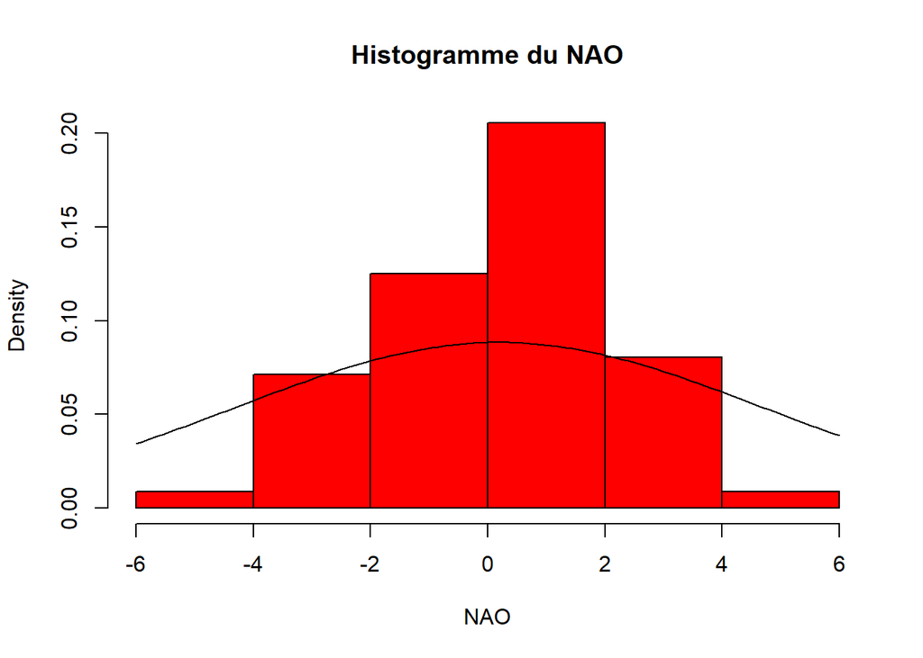

Comme on peut le voir, le test graphique n’est pas concluant. La courbe gaussienne ne semble pas intercepter la distribution des barres de l’histogramme.

## 2.2 Densité de l’arrivée des Hirondelles en Grandes Bretagnes

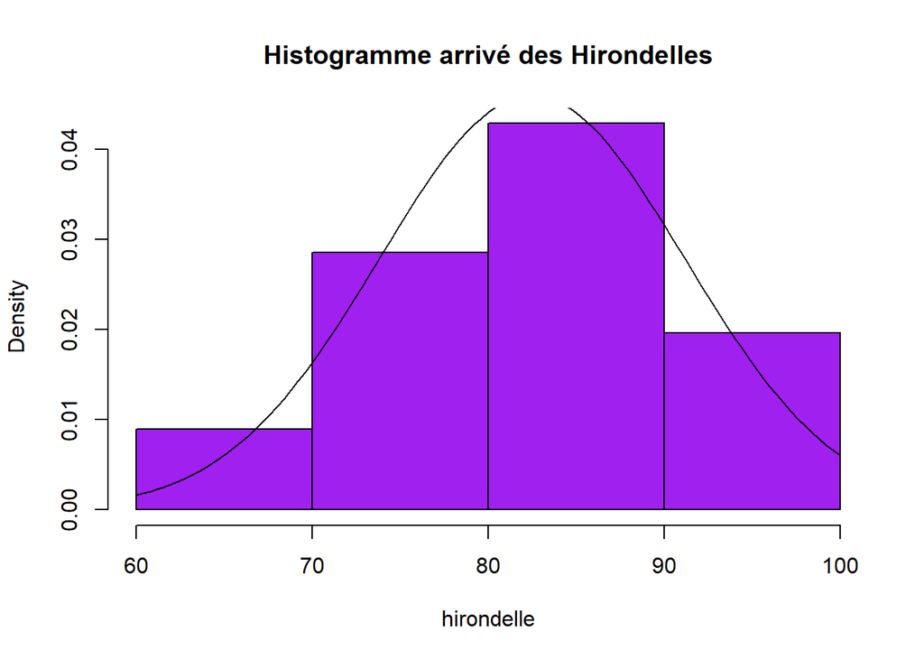

L’histogramme nous suggère que la densité suit une gaussienne

## 2.3 Distribution Température Europe et Asie

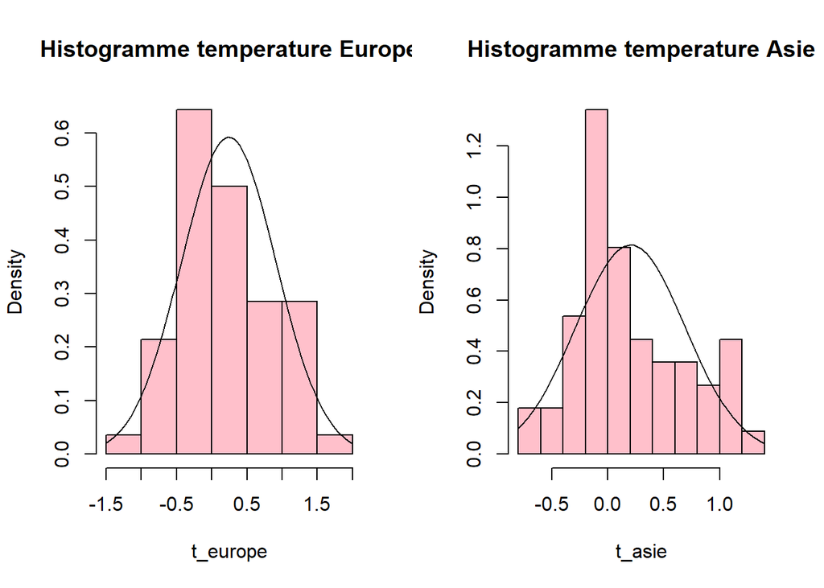

## 2.4 Anomalies de température

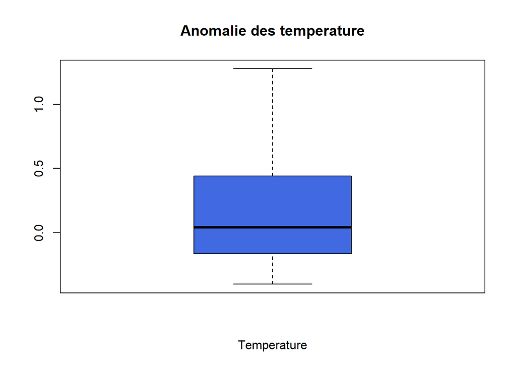

# 3 Indépendance des variables explicatives

## 3.1 Hypothèses

On a supposé au préalable que les variables liées aux températures étaient corrélées. Il peut être aussi intéressant en plus de vérifier celle-ci, de déterminer si les variations de température peuvent expliquer d’autres phénomènes tel que l’évolution de la migration des Hirondelles.

### 3.1.1 Test independance entre un phénomène de migration et les anomalies de température

```
##
##  Pearson's Chi-squared test
##
## data:  hirondelle and a_t_global
## X-squared = 3024, df = 2970, p-value = 0.2404
```

```
##
##  Pearson's Chi-squared test
##
## data:  cerisierKyoto and t_asie
## X-squared = 1064, df = 1045, p-value = 0.3344
```

Surprenamment le test d’indépendance accepte au seuil 5% l’hypothèse d’indépendance. Il est possible qu’un petit nombre de variable et leur qualités de mesures soient responsables d’une déviation de la valeur du test.

## 3.2 Étude de la corrélation entre les variables

[figure not shown]

D’après la matrice de corrélation et les nuages de points affichés par la fonction pairs, il semblerait qu’il existe des relations linéaires entre certaines variables par exemple: On observe une tendance linéaire à coefficient positif entre l’année de mesure et l’indice NAO.En résumé on note des phénomènes intéressant. On peut dire que les variables de température sont pour la majorité corrélé entre elles, on vérifie aussi une corrélation évidente avec ces variables et les anomalies de température. Un aspect plus intéressant est par exemple la présence d’un coefficient de corrélation proche de -1 entre l’arrivée du nombre d’Hirondelle en Grande Bretagne et les anomalies de températures globales des océans ce qui contredit notre test khi deux d’indépendance au préalable. On voit aussi que il y a une influence annuelle sur le nombre d’hirondelle (coefficient de corrélation -0.70). La fleuraison des cerisiers n’est pas significativement corrélée aux autres variables.

# 4 Régression linéaire simple

### 4.1.1 Hypothèse 1

On vérifie que notre matrice plan d’expérience est de rang plein , soit rang(X)=18

```
## [1] 18
```

Ensuite on regarde le coefficient de corrélation entre le nombre d’hirondelles qui arrivent en Grande Bretagne et la température moyenne en Europe.

```
## [1] -0.7923694
```

Le coefficient de corrélation est proche de 1 : On considère donc qu’il existe une probabilité non négligeable que l’évolution du nombre d’hirondelle soit en relation linéaire (à coefficient négatif) avec la température en Europe. Vérifions le en appliquant un modèle de regréssion linéaire simple.

### 4.1.2 Nuage de points

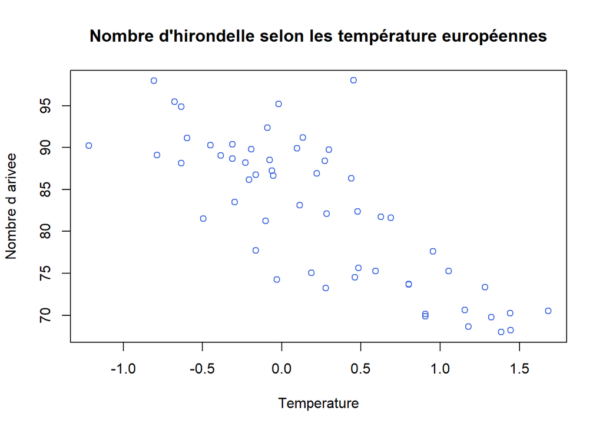

On peut dejà remarquer à partir de ce plot une tendance. En effet, on perçoit une évolution décroissante de la variable d’étude en fonction des températures. De plus, il ne semble pas vraiment y avoir d’observations atypiques dans ce modèle. Cependant un test visuel ne suffit pas pour conclure de manière raisonnable et il est utile de confirmer nos observations par l’utilisation d’un modèle linéaire.

#### 4.1.2.2 Régression ajusté

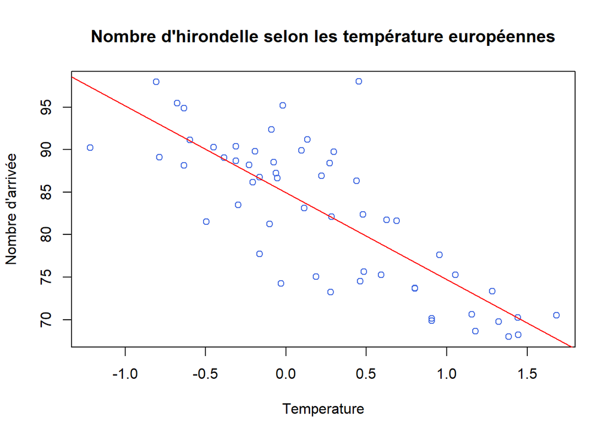

Observation : * notre regression linéaire intercepte bien le nuage de points, les point ajustés sont centrés dans le nuage de points et s’allignent correctement avec la droite. Ceci vérifie assez clairement la relation supposée auparavant.

```
##
## Call:
## lm(formula = hirondelle ~ t_europe, data = data_sg)
##
## Residuals:
##      Min       1Q   Median       3Q      Max
## -10.9929  -3.6904   0.1589   2.9516  17.6797
##
## Coefficients:
##             Estimate Std. Error t value Pr(>|t|)
## (Intercept)  84.9400     0.7594 111.856  < 2e-16 ***
## t_europe    -10.2161     1.0703  -9.545 3.47e-13 ***
## ---
## Signif. codes:  0 '***' 0.001 '**' 0.01 '*' 0.05 '.' 0.1 ' ' 1
##
## Residual standard error: 5.348 on 54 degrees of freedom
## Multiple R-squared:  0.6278, Adjusted R-squared:  0.621
## F-statistic:  91.1 on 1 and 54 DF,  p-value: 3.465e-13
```

La p value pour le coefficient Béta 0 et Béta 1 et largement infèrieure à tout les niveaux donc on rejette l’hypothèse H0 comme quoi ils sont nuls. On peut dire que le coefficient intercept est utile ce qui est vérifiable en traçant la régression linéaire sans ce coefficient.

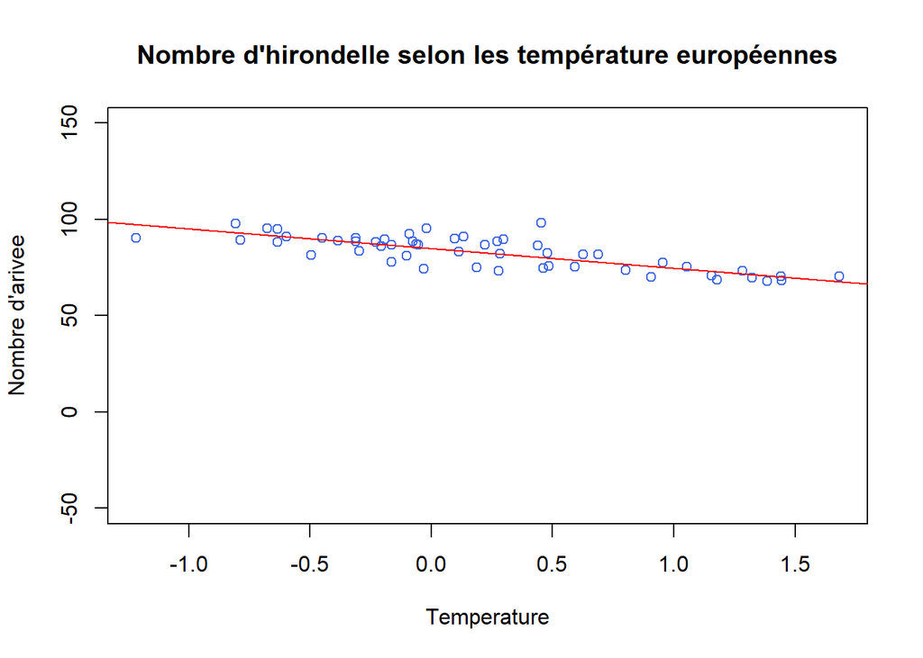

### 4.1.3 Étude des résidus

Il est simple de vérifier que nos résidus ne suivent pas une tendance particulière. En effet il est important de vérifier leur comportement aléatoire en traçant le plot des résidus estimés . De plus, les résidus studentisés sont utilisés dans les graphiques ils peuvent plus facilement être comparés entre eux puisque leur variance est supposée égale. Pour cela il est important de vérifier l’hypothèse de base du modèle linéaire que les erreurs sont homoscédastiques.

#### 4.1.3.1 Résidus éstimés

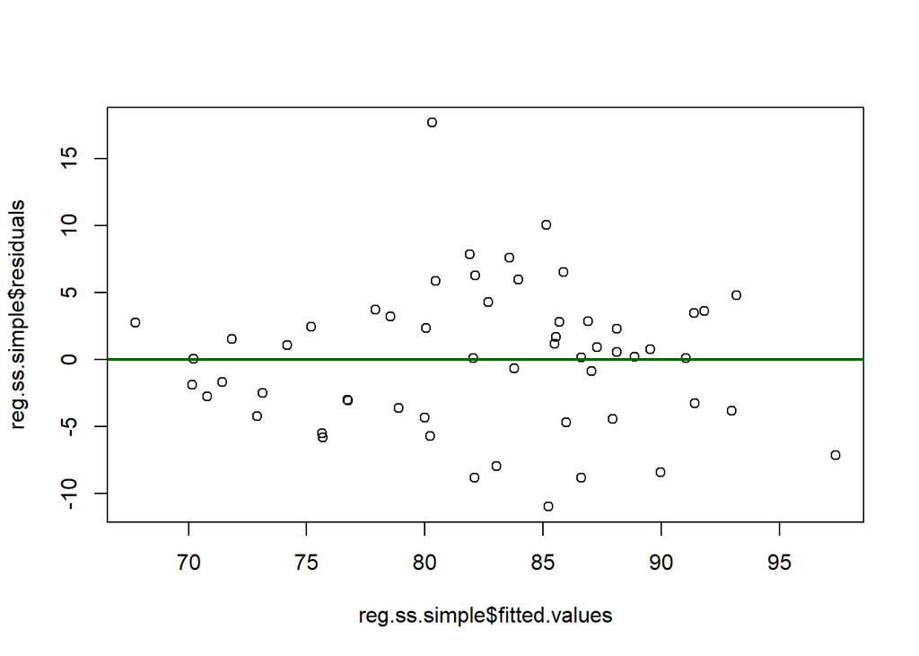

Visuelement, il semblerait que nos résidus soient concentrés dans certaines régions. Cependant le nombre de points est assez élevé ce qui semble être la raison de cette concentration. Globalement on observe que les points sont assez dispersé , l’hypothèse aléatoire de leur distribution n’est donc pas remise en cause.Ensuite on peut voir qu’ils sont globalement centrées autour de la droite d’équation y=0 ce qui semble confirmer l’hypothèse d’homogénéité de nos résidus. Il est possible de vérifier cette hypothèse plus rigoureusement grâce aux résidus studentisés.

#### 4.1.3.2 Comparaisons quantile empirique des résidus studentisé /quantile empirique loi de Student

Nous vérifions l’hypothèse de gaussiannité des résidus, nous avons vu en cours qu’il suffit de vérifier que l’estimateur des résidus studentisé suit une loi de Student.

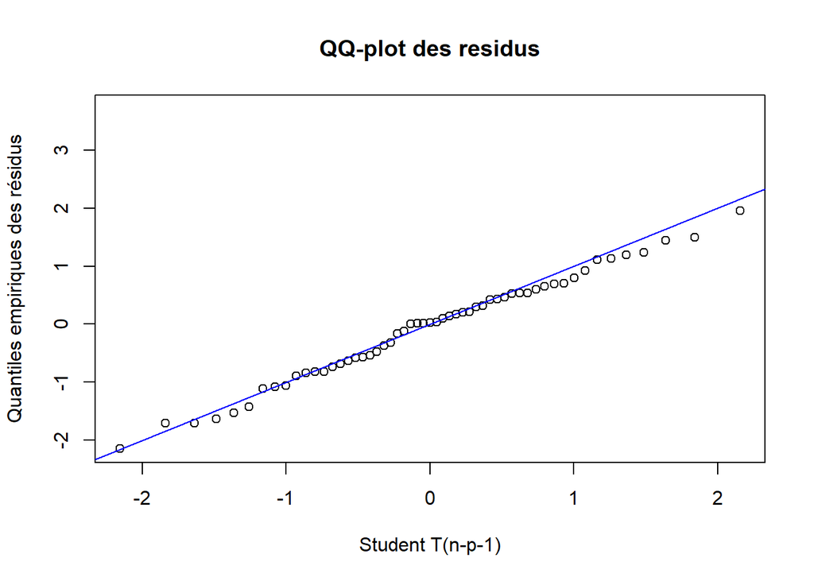

Le résultat est plutoôt claire; une grande majorité de nos quantiles se situent sur la droite d’équation x=y ce qui confirme l’hypothèse selon laquelle les résidus théoriques suivent la loi normale N(0,sd) .

## 4.2 Comparaisons résidus

Les résidus estimés n’étant pas à la même échelle que les résidus standardisés, il n’est pas utile de les comparer graphiquement. Ainsi on préfère comparer les résidus studentisés et les résidus standardisés

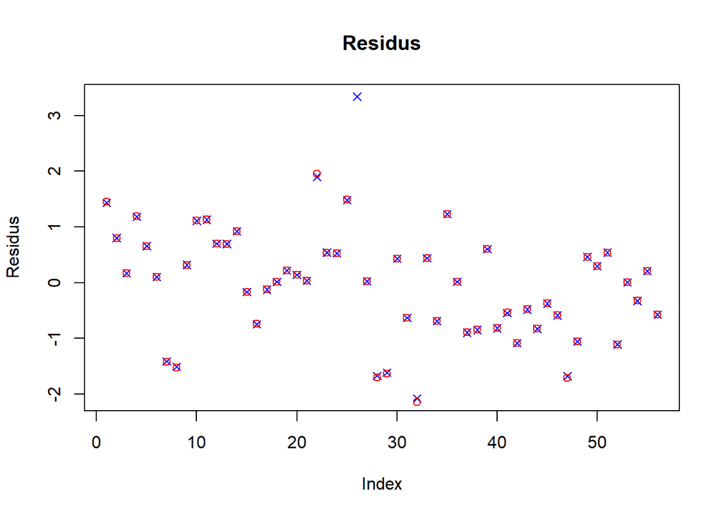

### 4.2.1 Résidus studentisés et valeurs abéranttes

L’ étude des résidus stundetisés nous permet d’obtenir de l’information sur la proportion de valeurs abérrantes dans nos points.

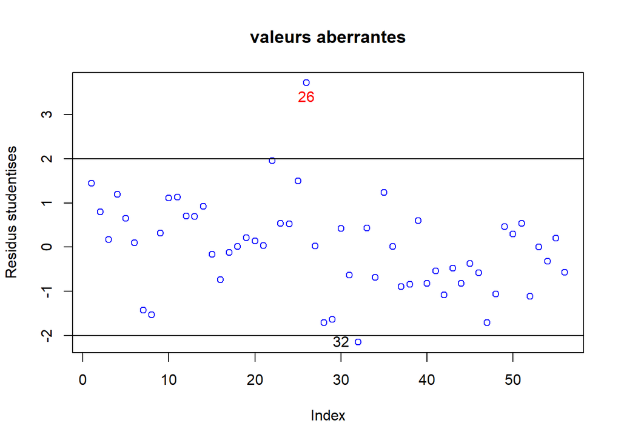

Pour affirmer que notre modèle ne contient pas trop de point abérrants nous vérifions que les points en dehors du bandeau situé entre [-2;2] ne représentent pas plus de 5% des points totaux. Il y a 2 valeurs abérrantes sur 56 points (environ 3%) de plus la valeur 32 n’est pas trop éloignée du seuil, contrairement à la valeur 26 qui peut être considérée comme abérrante . On en déduit que les observations sont globalement bonne sur notre modèle.

### 4.2.2 Données avec valeurs abéranttes

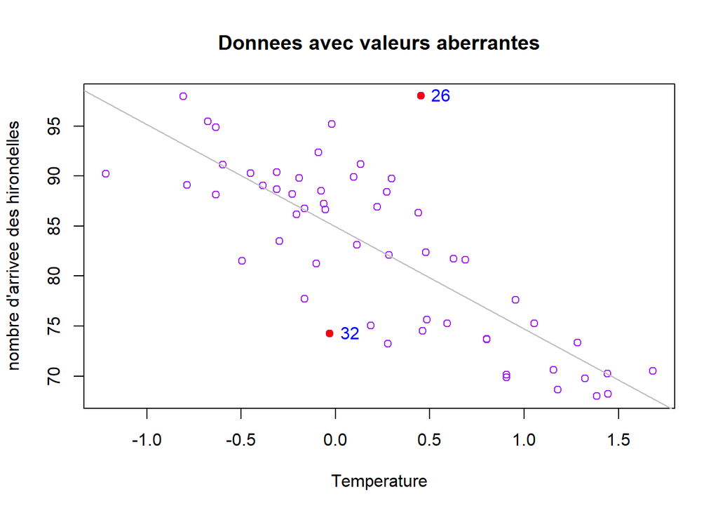

Le point numéro 26 semble être le plus éloigné de la droite de regression linéaire; il peut être judicieux de supprimer cette valeur pour améliorer le modèle.

### 4.2.3 Étude sur les points levier

#### 4.2.3.1 Levier

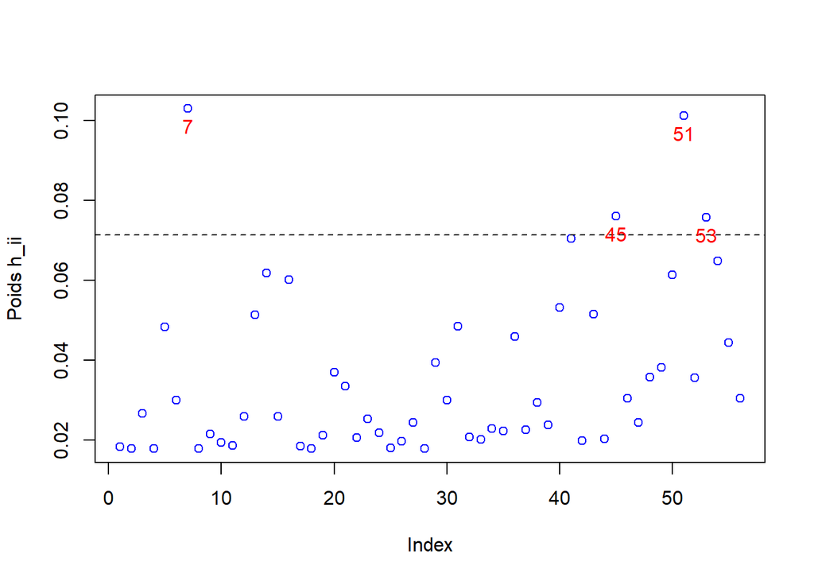

#### 4.2.3.2 distance de cook

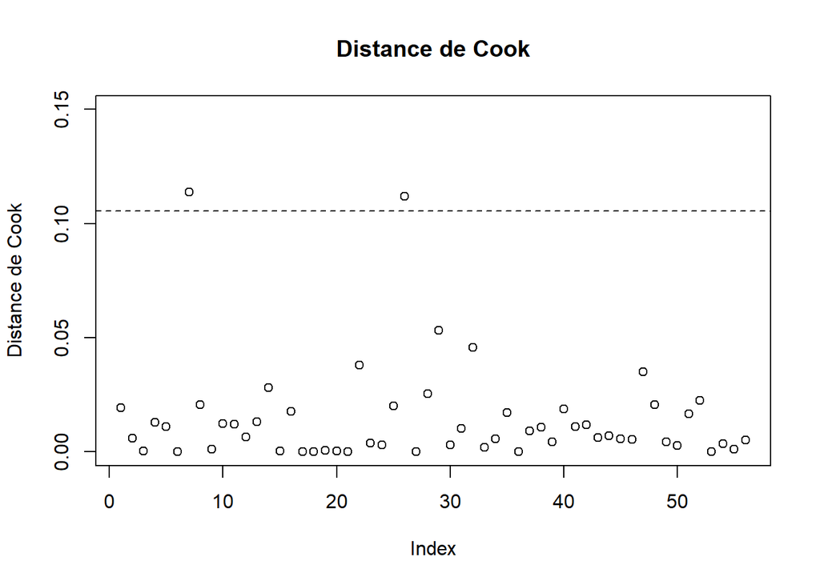

#### 4.2.3.3 Données valeurs aberrantes et points leviers

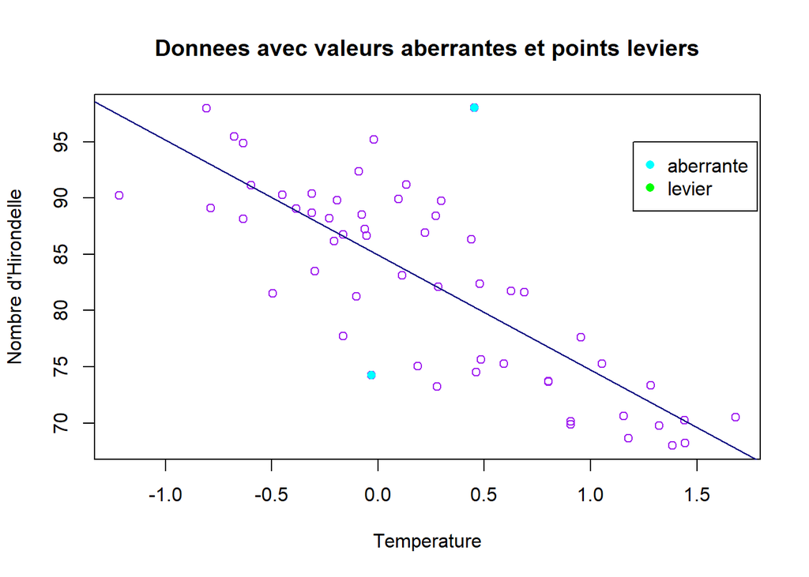

## 4.3 Intervalles de confiance et de prédictions

### 4.3.1 Intervalle de confiance et de prédictions fit données

[figure not shown]

### 4.3.2 Intervalle de confiance données

Une version plus esthétique est plus facile à apréhender visuellement.

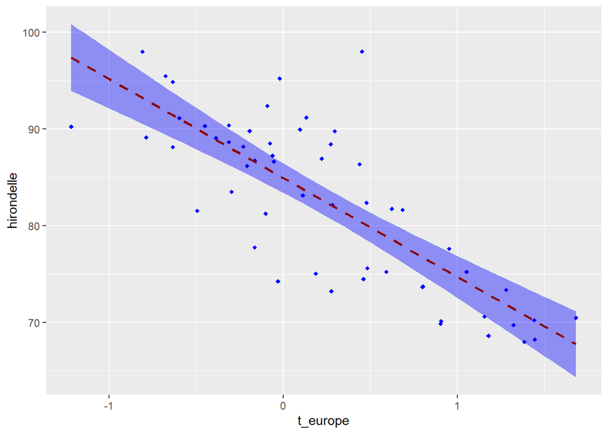

Il n’est pas choquant de voir que notre point aberrant sort de l’intervalle de prédiction.

## 4.4 Conclusion Régression linéaire simple

A la suite de la vérifications des hypothèses théoriques et de l’étude des résidus nous pouvons dire que notre modèle explicatif est cohérent et valide. Malgré cela le modèle ne suffit pas à prédire précisément les valeurs, on remarque une certaine dispersion de celle-ci. Cependant cette étude suggère que le nombre d’hirondelle migrants continuera à baisser au fur et à mesure des années. Cette étude nous permet d’estimer l’influence des changements climatiques sur le comportement des phénomènes liés à l’évolution de la faune. On voit donc ici, par une étude simple une des conséquence du régime shift annoncé dans l’article.

# 5 Modèle Multilinéaire

## 5.1 Hypothèse et selections de variables

Dans cette partie nous cherchons à determiner l’influence de nos variables sur les anomalies de températures terreste

L’objectif de cette démarche et d’estimer notre variable d’anomalie des température terrestre en fonction de toutes les autres variables de notre jeu de données. Pour cela il faudra vérifier les hypothèses du cours sur les résidus afin de pouvoir affimer la validité du modèle construit. Tout d’abord nous créeons notre regression linéaire multiple

### 5.1.1 Etude des résidus

#### 5.1.1.1 Normalité des résidus

##### 5.1.1.1.1 Comparaisons quantile résidus studensité empirique / quantile empirique loi de Student

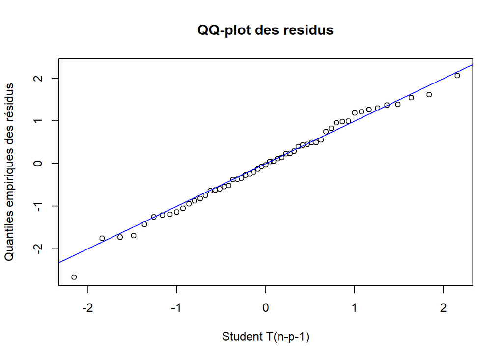

Les points interceptent bien la droite l’hypothèse de normalité de nos résidus est vérifié nous pouvons aussi les viualiser par un histogramme

##### 5.1.1.1.2 Histogramme Résidus

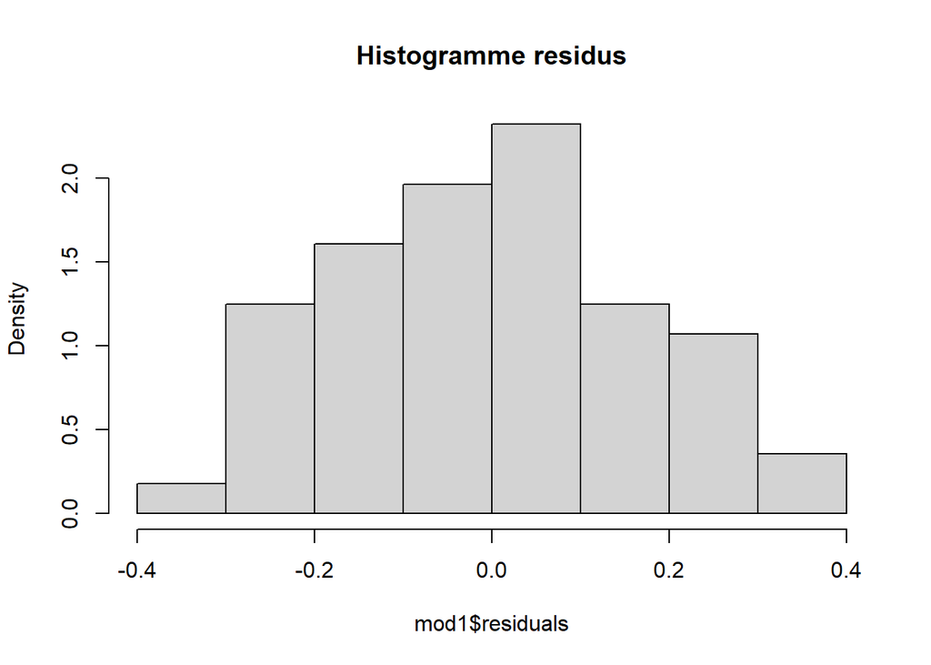

D’après les graphiques précédents le modèle est valide et les estimations correctes,le modèle estimé devrait présenter une bonne qualité d’adéquations aux données.

##### 5.1.1.1.3 Visualisation résidus

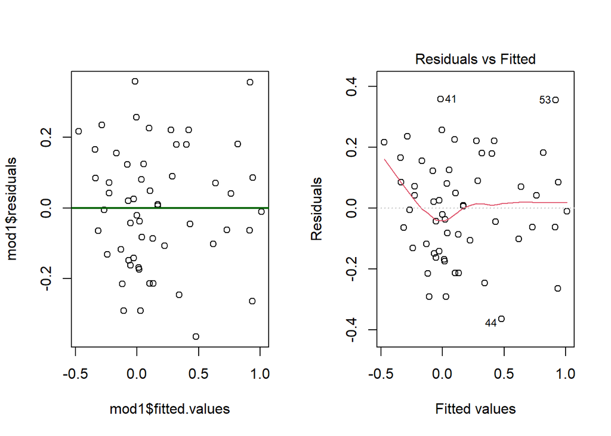

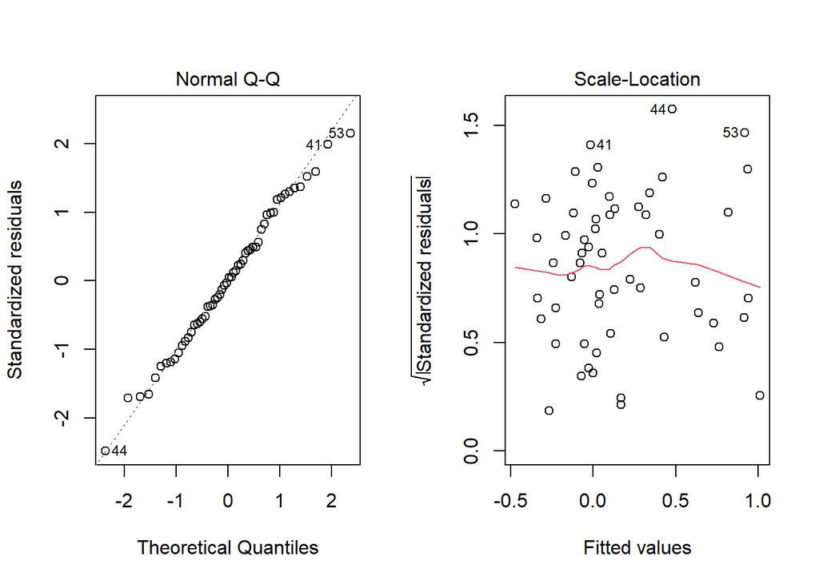

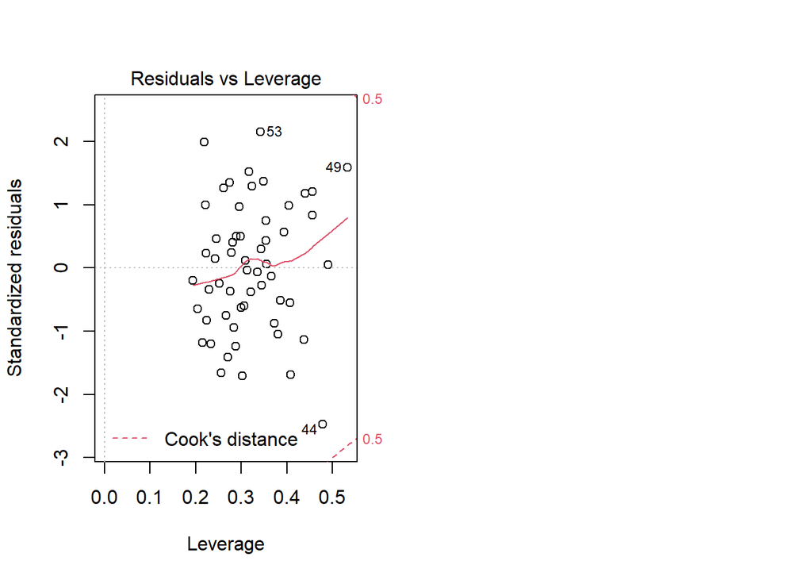

Il ne semble pas y avoir de tendance particulière les résidus sont bien gaussien et aléatoire.

Tout d’abord nous regardons les valeurs aberrantes.

#### 5.1.1.2 Valeurs aberanttes

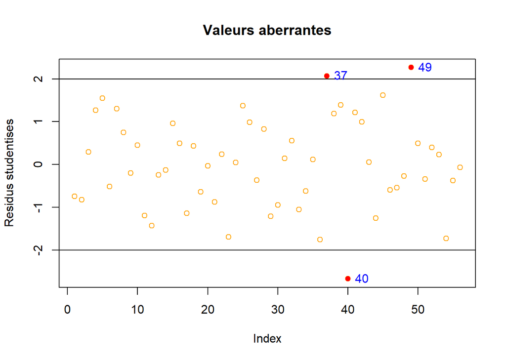

#### 5.1.1.3 Distances de cook

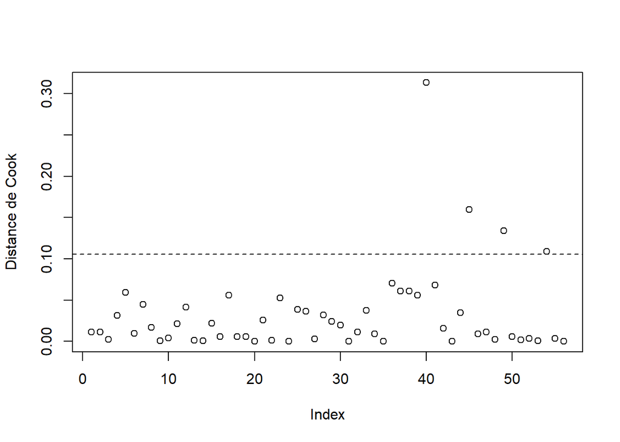

Un seul point est très dévié au dessus du 1er seuil. Il n’y a pas un grand nombre de points(4) qui peuvent fausser notre modèle.

### 5.1.2 Visualisation Modèle multilinéaire

#### 5.1.2.1 Sommaire du modèle

```
##
## Call:
## lm(formula = a_t_global ~ ., data = data_tmp)
##
## Residuals:
##      Min       1Q   Median       3Q      Max
## -0.36471 -0.12078  0.00035  0.12342  0.35794
##
## Coefficients:
##                                                     Estimate Std. Error t value
## (Intercept)                                       -4.093e+00  8.182e+00  -0.500
## Annee                                              2.671e-03  4.026e-03   0.663
## indice_NAO_DJFM                                    2.204e-02  2.280e-02   0.966
## Nombre_de_jours_de_neige_en_Suisse_DJFM            5.589e-03  2.850e-03   1.961
## Etendue_de_la_couverture_de_glace_en_Mer_Baltique  3.311e-04  6.339e-04   0.522
## Volume_de_glace_de_mer_en_Arctique_Septembre      -1.790e-03  1.822e-02  -0.098
## Floraison_des_cerisiers_à_Kyoto                   -7.473e-03  8.569e-03  -0.872
## Arrivée_de_l.Hirondelle_en_UK                     -7.433e-03  7.296e-03  -1.019
## Débit_de_la_rivière_Daugava_Hiver                 -2.287e-05  3.730e-04  -0.061
## Biomasse_phytoplanctonique_en_Mer_du_Nord         -2.231e-03  1.093e-01  -0.020
## Temperature_de_la_Mer_du_Nord                      1.969e-01  2.170e-01   0.907
## Temperature_Ocean_Arctique                         1.435e-01  1.970e-01   0.728
## Temperature_Pacifique_Nord                        -3.537e-01  3.805e-01  -0.930
## Temperature_Ocean_Atlantique_Nord                  4.841e-01  3.926e-01   1.233
## Temperature_Europe                                -1.182e-03  1.159e-01  -0.010
## Temperature_Asie                                   2.627e-01  1.328e-01   1.979
## Temperature_Ocean_Atlantique_Sud                   2.033e-01  2.798e-01   0.726
## Anomalies_des_temperatures_Ocean_Global            3.444e-01  8.755e-01   0.393
##                                                   Pr(>|t|)
## (Intercept)                                         0.6198
## Annee                                               0.5110
## indice_NAO_DJFM                                     0.3399
## Nombre_de_jours_de_neige_en_Suisse_DJFM             0.0573 .
## Etendue_de_la_couverture_de_glace_en_Mer_Baltique   0.6045
## Volume_de_glace_de_mer_en_Arctique_Septembre        0.9222
## Floraison_des_cerisiers_à_Kyoto                     0.3886
## Arrivée_de_l.Hirondelle_en_UK                       0.3147
## Débit_de_la_rivière_Daugava_Hiver                   0.9514
## Biomasse_phytoplanctonique_en_Mer_du_Nord           0.9838
## Temperature_de_la_Mer_du_Nord                       0.3700
## Temperature_Ocean_Arctique                          0.4710
## Temperature_Pacifique_Nord                          0.3585
## Temperature_Ocean_Atlantique_Nord                   0.2251
## Temperature_Europe                                  0.9919
## Temperature_Asie                                    0.0551 .
## Temperature_Ocean_Atlantique_Sud                    0.4720
## Anomalies_des_temperatures_Ocean_Global             0.6963
## ---
## Signif. codes:  0 '***' 0.001 '**' 0.01 '*' 0.05 '.' 0.1 ' ' 1
##
## Residual standard error: 0.2039 on 38 degrees of freedom
## Multiple R-squared:  0.8331, Adjusted R-squared:  0.7584
## F-statistic: 11.16 on 17 and 38 DF,  p-value: 5.657e-10
```

#### 5.1.2.2 représentation des nuages de point avec la droite d’ajustement

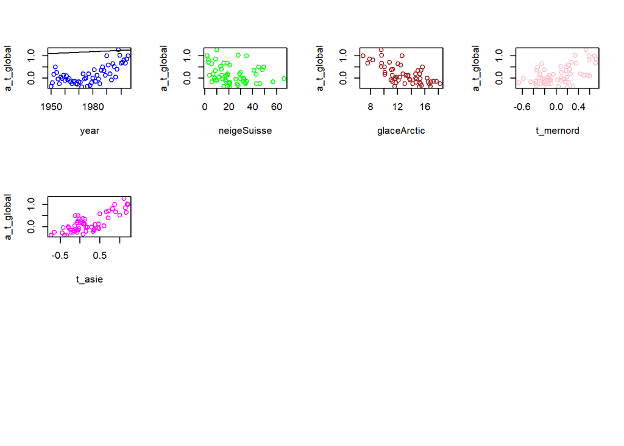

## 5.2 Sélection de variable

Pour améliorer notre modèle nous faisons une sélection des variables , pour cela nous utilisons la fonction regsubset et cherchons un modèle qui minimise le critère BIC

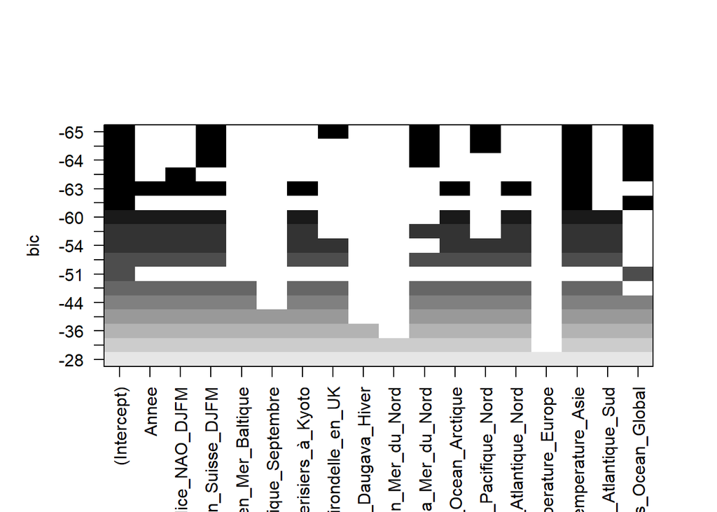

### 5.2.1 Modèle optimisé

#### 5.2.1.1 Nouveau modèle

```
##
## Call:
## lm(formula = a_t_global ~ t_atlsud + t_atlnord + t_mernord +
##     glaceBaltique + t_pacnord, data = data_tmp)
##
## Coefficients:
##   (Intercept)       t_atlsud      t_atlnord      t_mernord  glaceBaltique
##     0.0116153      0.6666898      0.9775417      0.2989250      0.0001213
##     t_pacnord
##     0.0278967
```

```
##
## Call:
## lm(formula = a_t_global ~ t_atlsud + t_atlnord + t_mernord +
##     glaceBaltique + t_pacnord, data = data_tmp)
##
## Residuals:
##      Min       1Q   Median       3Q      Max
## -0.40324 -0.15717 -0.01958  0.11885  0.50615
##
## Coefficients:
##                Estimate Std. Error t value Pr(>|t|)
## (Intercept)   0.0116153  0.0991198   0.117   0.9072
## t_atlsud      0.6666898  0.1485245   4.489 4.23e-05 ***
## t_atlnord     0.9775417  0.2033601   4.807 1.44e-05 ***
## t_mernord     0.2989250  0.1325896   2.255   0.0286 *
## glaceBaltique 0.0001213  0.0004968   0.244   0.8081
## t_pacnord     0.0278967  0.2516650   0.111   0.9122
## ---
## Signif. codes:  0 '***' 0.001 '**' 0.01 '*' 0.05 '.' 0.1 ' ' 1
##
## Residual standard error: 0.2235 on 50 degrees of freedom
## Multiple R-squared:  0.7363, Adjusted R-squared:  0.7099
## F-statistic: 27.91 on 5 and 50 DF,  p-value: 2.209e-13
```

Conclusion: notre modèle n’est pas optimale pour expliquer de manière vraiment précise nos variables. Il semble quand même valide à une certaine échelle car nos nuages de points suivent la même tendance que la droite de régression correspondante. La sélection de variable n’a pas amélioré significativement la précision de celui-ci.

# 6 Méthode ACP

Vu que nos données sont sous forme de séries temporelle, on va faire appel au package Zoo et Xts. Nous représentons d’abord graphiquement la série temporelle Anomalies_des_temperatures_terrestres_Global

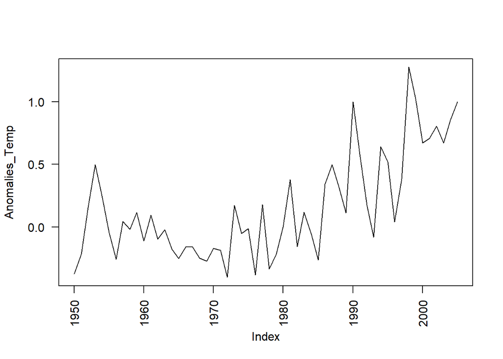

On remarque qu’à partir de l’année 1985, notre série temporelle a commencé à avoir une tendance.

## 6.1 Analyse ACP

Procédure: 1.D’abord on normalise et centralise le dataframe . 2.La fonction prcomp va calculer les valeurs propres ou faire une Décomposition en valeur singulière pour la matrice de covariance. 3.La fonction va trier les valeurs propres selons leur contribution à la variance 4.On construit une matrice de projection de K dimensions auquelle les plus représentatives. 5.A la fin, on transforme notre data et on fait la projection dans un sous espace de K dimensions pour soustraire les datas moins significatives ou corréllés.

```
## Importance of components:
##                          PC1    PC2    PC3     PC4     PC5     PC6     PC7
## Standard deviation     2.883 1.5049 1.2006 0.95793 0.83420 0.82166 0.76256
## Proportion of Variance 0.489 0.1332 0.0848 0.05398 0.04093 0.03971 0.03421
## Cumulative Proportion  0.489 0.6223 0.7071 0.76103 0.80197 0.84168 0.87589
##                            PC8     PC9    PC10    PC11    PC12    PC13    PC14
## Standard deviation     0.65794 0.64358 0.55879 0.51570 0.45740 0.40475 0.34854
## Proportion of Variance 0.02546 0.02436 0.01837 0.01564 0.01231 0.00964 0.00715
## Cumulative Proportion  0.90135 0.92572 0.94408 0.95973 0.97203 0.98167 0.98882
##                          PC15    PC16    PC17
## Standard deviation     0.2974 0.27099 0.16810
## Proportion of Variance 0.0052 0.00432 0.00166
## Cumulative Proportion  0.9940 0.99834 1.00000
```

[figure not shown]

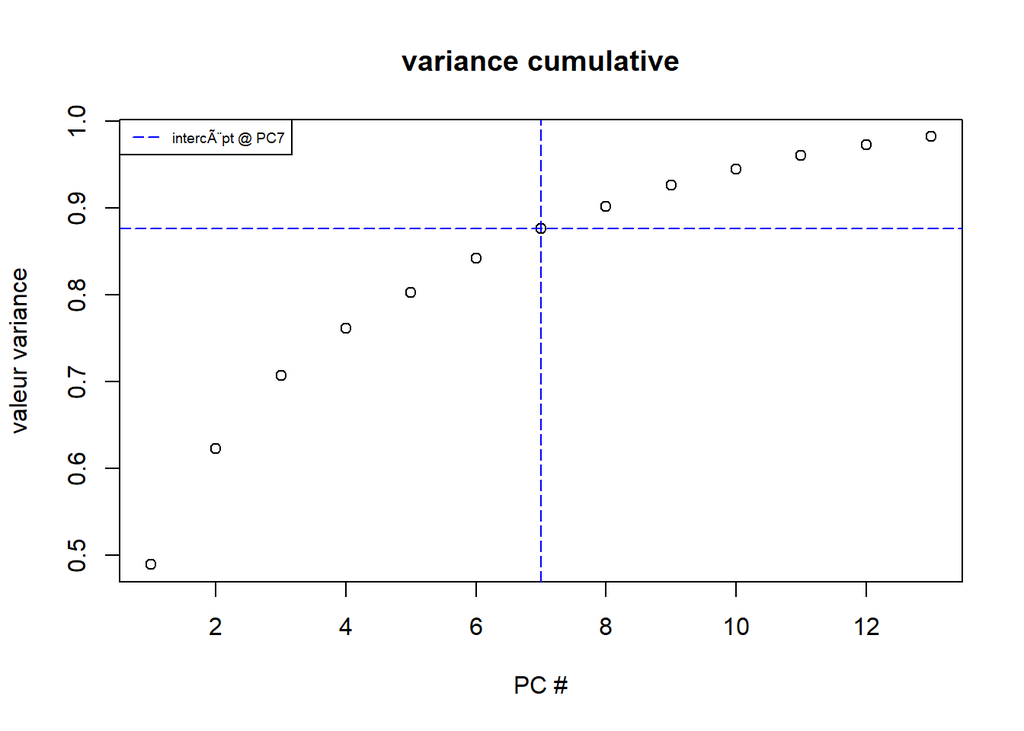

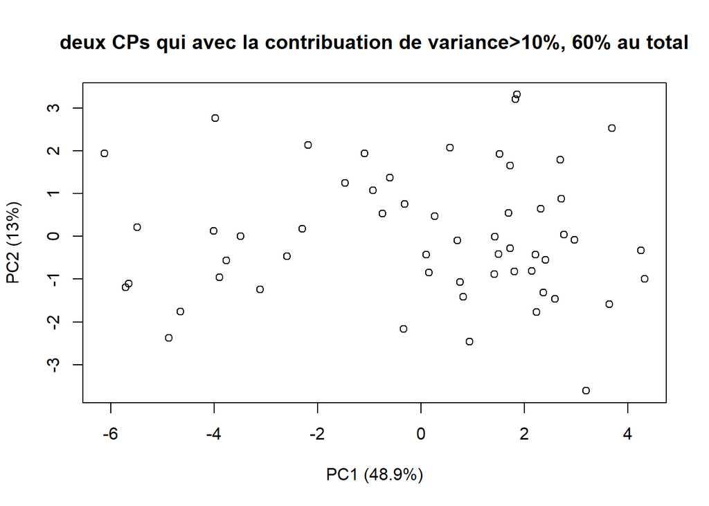

A partir du graphe au dessus, on peut tirer facilement que dans la situation où les données sont projetés dans un sous espace de dimension deux, “Temperature_de_la_Mer_du_Nord”, “Temperature_Ocean_Arctique” ,“Temperature_Europe”, “Debit_de_la_riviere_Daugava_Hiver”, sont corrélléz entre elles à cause de leur proximité régionale. Une autre variable proche mais un peu dévié est “indice_NAO_DJFM”. Les variables se situent dans la partie en pas en droite sont exactement anti corrélées avec les variables dessus, par exemple “Nombre_de_jours_de_neige_en_Suisse_DJFM”, car ils sont évidement anti-corrélées avec l’augmentation de la température.

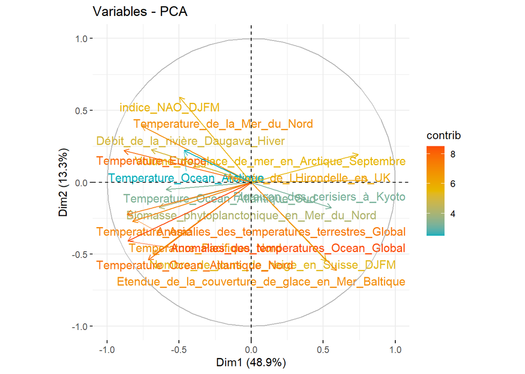

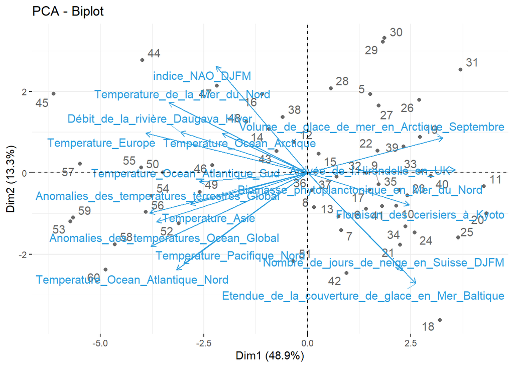

# 7 Conclusion

Dans cette étude statistique nous avons pu mettre en évidence des relations de dépendance entre plusieurs variables quantitatives, comme la relation entre la fréquence d’arrivée des hirondelles et la températures en Europe ou encore la fréquence de fleuraison des cerisiers à Kyoto et la température en Asie. Notre jeu de données présentait plusieurs valeur manquante ce qui nous à permis de prendre en compte les erreurs potentiels lié au manque de données. A la vue de certains graphiques et d’observation des modèles, on a pu voir que le jeu de données présentait un petit nombre d’outliers. De plus, du fait que chaque variable est exprimée selon des unités différentes ou en taux (pourcentage de la biomasse), il était difficile de visualiser nos résultats dans le cadre de la régression linéaire multiple. La regression linéaire multiple et la sélection de variable nous à permit d’éliminer plusieurs variable explicative, et de trouver le modèle le plus optimale pour la description de celle-ci. Néanmoins la visualisation des résultats nous a montré un défaut au niveau de l’approximation de la variable “Anomalie des températures globale” en fonction des températures dans différents océans.

Pour terminer, nous pouvons dire que le jeu de données est trop restreint et pas assez exploitable.

Mais l’intérêt général de cette étude reste la visualisation des changements des régimes et leurs effets sur nos variables. Donc on doit faire appel à des méthodes de traitement des séries temporelles plus appropriés pour évaluer les modèles climatiques et estimer les changements climatiques futurs.